# E-Commerce Experiment Code

**Goal:** The goal of this notebook is to recreate steps necessary to run a basic experiment on conversion rates. For the sake of realism, the notebook processes Google Analytics 4 event data directly from Google Big Query. The public event data comes from the Google Merchandise e-commerce website at https://shop.googlemerchandisestore.com between 11/1/2020 and 1/31/2021.

For simplicity, the code will evaluate one main metric, purchase conversion rate. In a real experiment, it would be important to discuss the benefits and downsides of chosen metrics. For example, low frequency events like purchase rate require extremely large sample sizes or must detect very large effects.

The proposed experiment page (a.k.a. evaluation page) will be a landing page hosting apparel named 'Apparel | Google Merchandise Store.' I've chosen to evaluate a 1 month window from 12/1 to 12/28. When possible, it is recommended that full weeks be evaluated.

**Overview:**

1. Review Historical Activity for Chosen Metric (II(a)-(b))
2. Calculate Required Sample Size (II(c))
3. Create Table with Covariates for Balance Check (III)
4. Run Experiment Result Checks like Balance (V)
5. Evaluate Fake Experiment Group Results (VI)
6. Logistic Regression Set Up (VII)

**Notes:**

1. In a real experiment, there would likely be a number of secondary and guardrail metrics. If you test revenue, it is usually best practice to select at least one user retention based guardrail metric. Short term revenue growth is not worth losing your most dedicated visitors.
2. Be careful how you interpret Secondary metrics. If we look at everything under the sun, there is a high likelihood you will find something that looks like an impact. To account for this, in statistics, if more than one primary metric is tested, confidence intervals are lengthened by multiple comparison adjustments like Benjamini and Hochberg. This may change your statistically significant result to not significant. If you discover something interesting in secondary metrics, best practice is to retest it as a primary metric.

**Source:** https://developers.google.com/analytics/bigquery/web-ecommerce-demo-dataset

# I. Set Up Connection to Big Query Using Service Account Key

# II. Big Query Large Ecommerce Data EDA

**Source:** https://developers.google.com/analytics/bigquery/web-ecommerce-demo-dataset

## A. Query E-Commerce Data to Get Daily Conversions within 1 Day of Evalution Page Visit

**Goal:** This section querys Big Query's public e-commerce data to calculate conversions within one day of visiting a designated **evaluation page ('Apparel | Google Merchandise Store')**.

**Note:** This timeseries code double counts visitor conversions for customers visiting the apparel page on seperate days and then converting within 1 day of each visit. If necessary, we can estimate how many users fit into this category.

```
Downloading: 100%|█████████████████████████████████████████████████████████████|
```

|  | page_visit_date | visitor_count | purchaser_count | purchase_count | bookings |
| --- | --- | --- | --- | --- | --- |
| 0 | 2021-01-07 | 720 | 5 | 19 | 337.0 |
| 1 | 2020-12-13 | 738 | 15 | 70 | 1324.0 |
| 2 | 2020-12-30 | 671 | 3 | 15 | 309.0 |
| 3 | 2020-11-19 | 293 | 13 | 251 | 3543.0 |
| 4 | 2020-11-17 | 282 | 17 | 75 | 1668.0 |
| ... | ... | ... | ... | ... | ... |
| 87 | 2021-01-09 | 703 | 3 | 6 | 192.0 |
| 88 | 2021-01-19 | 581 | 13 | 51 | 899.0 |
| 89 | 2020-12-29 | 715 | 2 | 5 | 136.0 |
| 90 | 2021-01-12 | 701 | 6 | 9 | 294.0 |
| 91 | 2020-11-16 | 243 | 14 | 69 | 1433.0 |

92 rows × 5 columns

**Table Description:** The table above organizes site traffic by daily visits to a selected evaluation page. ie The Apparel Page. The table also aggregates daily unique visitors who triggered various conversions within 1 day of landing on the evaluation page. Conversions tracked are daily purchase counts, purchasers, and bookings generated.

## B. Estimated Evaluation Page Traffic and Conversion Rates

### i. Plots

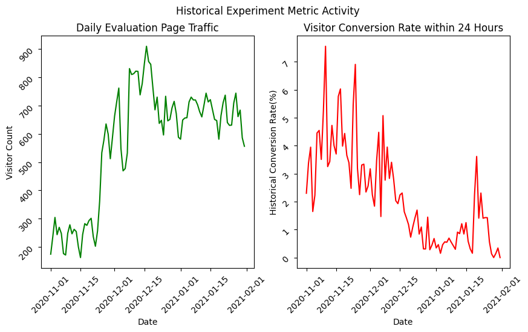

**Conclusions:**

a) Plot 1 shows that daily page traffic jumped substantially from November to January.

**Notes:** In this case, the only data available is from November 2020 through January 2021. **As a rule of thumb, we should not run experiments or estimate conversion rates from holidays or sale months like black friday unless central to what is being tested.**

### ii. Monthly Conversion Rates

|  | Page Visit Year | Month | Conversion_Rate(%) | purchase_count | Daily_Visitors |
| --- | --- | --- | --- | --- | --- |
| 2 | 2020 | November | 3.758676 | 2228 | 312.0 |
| 0 | 2020 | December | 1.946162 | 2376 | 709.0 |
| 1 | 2021 | January | 0.829219 | 669 | 673.0 |

**Notes:** There are many ways to estimate control page visit conversion rates for minimal detectable effects in sample size calculations. If you have fairly stable conversion rates, a fairly naive method involves simply taking the last month while avoiding months with holidays or unusual activity. Alternatively, we can get a pretty good idea of expected conversion rates by taking the rate of growth YoY of the prior month times the last years estimate for the experiment's month.

Either way, its helpful to review at least 14 months to two years of time series data to see if estimates are historically reasonable.

**CAUTION:** 1) Averaging many months of historical data can be misleading. Changing trends can dramatically influence more recent rates. 2) When picking the effect size you want to test for, it is important to consider what effect size you want to claim victory for. It is not good practice to claim effects smaller than your Minimum Detectable Effect size were statistically significant.

## C. Power Analysis

**Step 1:** Calculate power accrued over time for various effect sizes given estimated daily traffic.

i. Chosen Parameters

ii. For Loop Estimating Accrued Power over Time for Chosen Effect Sizes

**Step 2:** Reformat accrued power table for plotting.

|  | 5 | 10 | 15 | 20 | 25 | 30 |
| --- | --- | --- | --- | --- | --- | --- |
| 0 | 0.051454 | 0.055697 | 0.062578 | 0.071979 | 0.083801 | 0.097952 |
| 1 | 0.052913 | 0.061439 | 0.075345 | 0.094462 | 0.118627 | 0.147635 |

**Table:** This table stores estimate accrued power over time (in days) for different effect size estimates given a daily traffic estimate of 673 and a conversion rate estimate of 3%.

**Step 3:** Plot Power for Different Effect Sizes Over Times

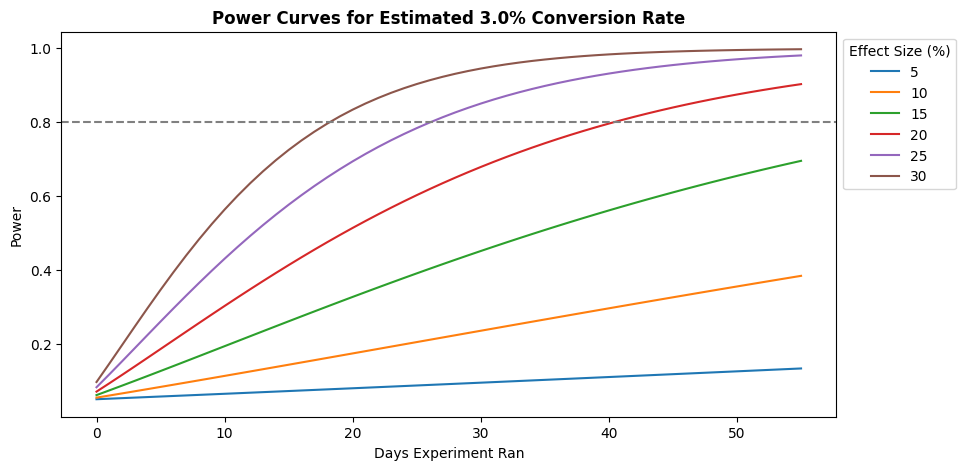

**Conclusion:** Generally, our goal is to evaluate an effect size of 5% with at least .8 power. However, for this very low conversion rate, a 5% lift is impractical and has very low power. This leaves us with two options. a) Choose a higher effect size and miss out on small impacts. b) Attempt to find a metric correlated with the conversion rate of interest but with a higher estimated control rate.

**Note:**

1. Unless experiment is run on logged in users only, time periods over which visitor activity can be linked together continue to shrink due to browser changes. Running experiments for longer than 1 month, risks double exposure to treatment and control for repeat visitors where tracking lapsed.
2. For smaller sample sizes and tiny conversion rates, traditional Wald confidence interval calculations may need to be adjusted to remain at 95%.

**Step 4:** Calculate required sample size for 23% Lift MDE.

**Required n Per Group (n)** = $\frac{(\frac{\alpha}{2}_{crit} + 1-\beta_{crit})^2*2\sigma^2}{\delta^2} $

**where** $\delta$ is the absolute Minimum Detectable Effect size.

**Note:** In some implementations, unequal groups resluts in increasing one $\sigma^2$ by a ratio of control / variant groups. See Georgiev at 11.

```
Required Sample Size Per Group: 9596 participants.
Estimated Duration: 30 days.
```

# III. User Level - Experiment with Covariate Table

**Goal:** This section explores calculating commonly tracked features associated with e-commerce experiments. If there are strong correlations to the outcome of interest (ie conversion rate), features might be used to identify potential imbalances from bad randomizations or in a regression to remedy minor imbalances / increase precision. For a feature to be useable, it must accrue before exposure to the experiment. For continuous features, they should be uncorrelated with each other and linearly related to continuous outcome metrics.

**EXPERIMENT PAGE**: 'Apparel | Google Merchandise Store'

**EVALUTION PERIOD:** 12/01/2020 to 12/28/2020

**FULL DATA RANGE:** 11/01/2020 to 1/31/2021

**COLUMN NAME STRUCTURE**

**Note:** *To make columns easier to identify, most columns employ the following naming structure.*

**{ Covariate(cov_) / Outcome(oc_) } { Period_Days (ie in/ pre_2/ pre_7 / pre_8_14 / post) } { Page / Event Level(ie exp_/sess_) }_{ Metric Name } { Continuous(cnt)/ Indicator(ind)/ Categorical(cat) }**

**PERIODS**

**|14 Days Prior|** *--pre_8_14--* **|7 Days Prior|** *--pre_7--* **|2 Days Prior|** *--pre_2--* **|1st Exp Page Visit|** *--in--* **|Experiment End|** *--post--* **|Data Range End|**

- 2/7/14 Days Before First Exposure (pre_)
- From First Experiment Page Exposure to Evaluation Period End (in_)
- From Evaluation Period End to Data Range End (post_)

### EXPERIMENT TABLE COLUMNS

**FIRST EXPERIMENT EXPOSURE**

- **Note:** *1) A user was deemed part of the experiment if they visted the apparel page between the evaluation period start_date (12-01-2020) and end_date (12-28-2020). Apparel page visitors were identified using the event_params column where* **'page_title' = 'Apparel | Google Merchandise Store'** *and* **page_view** *events. 2) Pre-period lifetime revenue (cov_pre_ltv_revenue_cnt) was calculated using user_ltv.revenue column at first visit.*

**user_pseudo_id**: A unique user id assigned to visitors in GA4 to track them across sessions.

**first_exposure_ts**: A timestamp for the user's first experiment page visit during the evaluation period.

**cov_fe_day_of_week_cat:** The day of week of the user's first experiment page visit during the evaluation period.

**pre_2_ts:** A timestamp for 48 hours before the user's first experiment page visit during the evaluation period.

**cov_pre_ltv_revenue_cnt:** User lifetime spending accrued before the user's first experiment page visit during the evaluation period.

**cov_treatment_status_ind:** A fake treatment status assigned to users based on odd/even row number.

**DEMOGRAPHICS**

- **Note:** *1) Further pre-count cleaning of missing value categories could improve data quality. 2) These columns were aggregated using the* **device.___** *columns and* **user_first_touch_timestamp**.*

**cov_in_exp_days_since_first_touch_cnt:** Days since the user's first site visit.

**cov_in_exp_device_type_cat:** Visitor device type(s) identified during evaluation period. Users with multiple sources marked as multi_device.

**cov_in_exp_device_language_cat:** Visitor device language(s) identified during evaluation period. Users with multiple sources marked as multi_language.

**cov_in_exp_country_cat:** Visitor countries identified during evaluation period. Users with multiple sources marked as multi_country.

**cov_in_exp_platform_type_cat:** Visitor platform name(s) identified during evaluation period. Users with multiple sources marked as multi_platform.

**cov_in_exp_traffic_source_cat:** Visitor source name(s) identified during evaluation period. Users with multiple sources marked as multi_source.

**ENGAGEMENT TIME**

- **Note:** *These columns were calculated using* **'engagement_time_msec'** *from event_params column.*

**cov_pre_7_exp_engage_mins_cnt:** Prior Apparel page(exp) engagement minutes accrued within 7 days of first experiment page exposure during the evaluation period.

**cov_pre_7_otr_engage_mins_cnt:** Prior non-Apparel page(otr) engagement minutes accrued within 7 days of first experiment page exposure during the evaluation period.

**cov_pre_8_14_exp_engage_mins_cnt:** Prior Apparel page(exp) engagement minutes accrued within 8 to 14 days of first experiment page exposure during the evaluation period.

**cov_pre_8_14_otr_engage_mins_cnt:** Prior non-Apparel page(otr) engagement minutes accrued within 8 to 14 days of first experiment page exposure during the evaluation period.

**oc_in_exp_engage_mins_cnt:** Apparel page(exp) engagement minutes accrued between first experiment page exposure and evaluation period end.

**oc_in_otr_engage_mins_cnt:** Non-Apparel page(otr) engagement minutes accrued between first experiment page exposure and evaluation period end.

**post_exp_engage_mins_cnt:** Apparel page(exp) engagement minutes accrued after evaluation period end.

**post_otr_engage_mins_cnt:** Non-Apparel page(otr) engagement minutes accrued after evaluation period end.

**DAYS ACTIVE**

- **Note:** *These columns were calculated using* **session_start** *event and event_dates.*

**cov_pre_7_sess_days_active_cnt:** Days active accrued within 7 days of first experiment page exposure during the evaluation period.

**cov_pre_7_sess_session_cnt:** Sessions accrued within 7 days of first experiment page exposure during the evaluation period.

**cov_pre_8_14_sess_days_active_cnt:** Days active accrued within 8 to 14 days of first experiment page exposure during the evaluation period.

**cov_pre_8_14_sess_session_cnt:** Sessions accrued within 8 to 14 days of first experiment page exposure during the evaluation period.

**oc_in_sess_days_active_cnt:** Days active accrued between first experiment page exposure and evaluation period end.

**oc_in_sess_session_cnt:** Sessions accrued between first experiment page exposure and evaluation period end.

**post_sess_days_active_cnt:** Days active accrued after evaluation period end.

**post_sess_session_cnt:** Sessions accrued after evaluation period end.

**CONVERSION COUNTS**

- **Note:** *1) For higher quality scroll event, adjust to only count scrolls reaching bottom of page or scroll time. 2) Current implementation of events can be viewed at https://shop.googlemerchandisestore.com under Network Payload for:* **collect?v=2**.

**cov_pre_2_all_scroll_cnt:** # of scroll events accrued within 2 days of first experiment page exposure during the evaluation period. **This event is tracked when a user scrolls down a visited page.**

**cov_pre_2_all_view_item_cnt:** # of view_item events accrued within 2 days of first experiment page exposure during the evaluation period. **This event is tracked when a user views an item page.**

**cov_pre_2_all_view_promo_cnt:** # of view_promotion events accrued within 2 days of first experiment page exposure during the evaluation period. **This event is tracked when a user views a banner promotion shown at the top of some pages.**

**cov_pre_2_all_add_cart_cnt:** # of add_to_cart events accrued within 2 days of first experiment page exposure during the evaluation period. **This event is tracked when a user adds an item to their cart.**

**cov_pre_2_all_checkout_strt_cnt:** # of begin_checkout events accrued within 2 days of first experiment page exposure during the evaluation period. **This event is tracked when a user begins the checkout process.**

**cov_pre_2_all_select_item_cnt:** # of select_item events accrued within 2 days of first experiment page exposure during the evaluation period. **This event is tracked when a user selects an item from a list.**

**cov_pre_2_all_select_promo_cnt:** # of select_promotion events accrued within 2 days of first experiment page exposure during the evaluation period. **This event is tracked when a user clicks on a banner promotion shown at the top of some pages.**

**oc_in_all_scroll_cnt:** # of scroll events accrued between first experiment page exposure and evaluation period end. **This event is tracked when a user scrolls down a visited page.**

**oc_in_all_view_item_cnt:** # of view_item events accrued between first experiment page exposure and evaluation period end. **This event is tracked when a user views an item page.**

**oc_in_all_view_promo_cnt:** # of view_promotion events accrued between first experiment page exposure and evaluation period end. **This event is tracked when a user views a banner promotion shown at the top of the page.**

**oc_in_all_add_cart_cnt:** # of add_to_cart events accrued between first experiment page exposure and evaluation period end. **This event is tracked when a user adds an item to their cart.**

**oc_in_all_checkout_strt_cnt:** # of begin_checkout events accrued between first experiment page exposure and evaluation period end. **This event is tracked when a user begins the checkout process.**

**oc_in_all_select_item_cnt:** # of select_item events accrued between first experiment page exposure and evaluation period end. **This event is tracked when a user selects an item from a list.**

**oc_in_all_select_promo_cnt:** # of select_promotion events accrued between first experiment page exposure and evaluation period end. **This event is tracked when a user clicks on a banner promotion shown at the top of the pages.**

**USER REVENUE**

- **Note:** *These columns were calculated using* **purchase** *event and* **ecommerce.total_item_quantity / event_value_in_usd** *columns.*

**cov_pre_7_purch_purchase_cnt:** User item purchase count accrued within 7 days of first experiment page exposure during the evaluation period.

**cov_pre_7_purch_spending_usd_cnt:** User spending accrued within 7 days of first experiment page exposure during the evaluation period.

**cov_pre_8_14_purch_purchase_cnt:** User item purchase count accrued within 8 to 14 days of first experiment page exposure during the evaluation period.

**cov_pre_8_14_purch_spending_usd_cnt:** User spending accrued within 8 to 14 days of first experiment page exposure during the evaluation period.

**oc_in_purch_purchase_cnt:** User item purchase count accrued between first experiment page exposure and evaluation period end.

**oc_in_purch_spending_usd_cnt:** User spending accrued between first experiment page exposure and evaluation period end.

**post_purch_purchase_cnt:** User item purchase count accrued after evaluation period end.

**post_purch_spending_usd_cnt:** User spending accrued after evaluation period end.

```
Downloading: 100%|█████████████████████████████████████████████████████████████|
```

|  | user_pseudo_id | first_exposure_ts | cov_fe_day_of_week_cat | pre_2_ts | cov_pre_ltv_revenue_cnt | cov_treatment_status_ind | cov_in_exp_days_since_first_touch_cnt | cov_in_exp_device_type_cat | cov_in_exp_device_language_cat | cov_in_exp_country_cat | ... | oc_in_all_select_item_cnt | oc_in_all_select_promo_cnt | cov_pre_7_purch_purchase_cnt | cov_pre_7_purch_spending_usd_cnt | cov_pre_8_14_purch_purchase_cnt | cov_pre_8_14_purch_spending_usd_cnt | oc_in_purch_purchase_cnt | oc_in_purch_spending_usd_cnt | post_purch_purchase_cnt | post_purch_spending_usd_cnt |
| --- | --- | --- | --- | --- | --- | --- | --- | --- | --- | --- | --- | --- | --- | --- | --- | --- | --- | --- | --- | --- | --- |
| 0 | 1355146.5368216305 | 2020-12-05 16:21:51.644187+00:00 | Sat | 2020-12-03 16:21:51.644187+00:00 | 0.0 | 1 | 0 | desktop | en-us | Spain | ... | 0 | 0 | 0 | 0.0 | 0 | 0.0 | 0 | 0.0 | 0 | 0.0 |
| 1 | 1473507.3513636237 | 2020-12-05 07:28:12.549248+00:00 | Sat | 2020-12-03 07:28:12.549248+00:00 | 0.0 | 1 | 0 | desktop | en-us | Singapore | ... | 0 | 0 | 0 | 0.0 | 0 | 0.0 | 0 | 0.0 | 0 | 0.0 |
| 2 | 1502684.5928418976 | 2020-12-05 17:06:47.674167+00:00 | Sat | 2020-12-03 17:06:47.674167+00:00 | 0.0 | 0 | 6 | mobile | None | United States | ... | 0 | 0 | 0 | 0.0 | 0 | 0.0 | 0 | 0.0 | 0 | 0.0 |
| 3 | 2232198.6371873310 | 2020-12-05 17:50:56.813868+00:00 | Sat | 2020-12-03 17:50:56.813868+00:00 | 0.0 | 1 | 11 | desktop | en-us | United States | ... | 2 | 0 | 0 | 0.0 | 0 | 0.0 | 2 | 58.0 | 0 | 0.0 |
| 4 | 2936713.3976633179 | 2020-12-05 20:25:06.440856+00:00 | Sat | 2020-12-03 20:25:06.440856+00:00 | 0.0 | 1 | 0 | desktop | en-us | Finland | ... | 0 | 0 | 0 | 0.0 | 0 | 0.0 | 0 | 0.0 | 0 | 0.0 |
| ... | ... | ... | ... | ... | ... | ... | ... | ... | ... | ... | ... | ... | ... | ... | ... | ... | ... | ... | ... | ... | ... |
| 19422 | 80857996.5792100608 | 2020-12-01 16:33:04.362203+00:00 | Tue | 2020-11-29 16:33:04.362203+00:00 | 0.0 | 1 | 0 | mobile | zh | Singapore | ... | 0 | 0 | 0 | 0.0 | 0 | 0.0 | 0 | 0.0 | 0 | 0.0 |
| 19423 | 86883593.4331238726 | 2020-12-01 22:45:05.299786+00:00 | Tue | 2020-11-29 22:45:05.299786+00:00 | 0.0 | 0 | 0 | mobile | en-us | Thailand | ... | 0 | 0 | 0 | 0.0 | 0 | 0.0 | 0 | 0.0 | 0 | 0.0 |
| 19424 | 89337508.7164762056 | 2020-12-01 11:59:34.137315+00:00 | Tue | 2020-11-29 11:59:34.137315+00:00 | 0.0 | 0 | 0 | desktop | en-us | Japan | ... | 0 | 0 | 0 | 0.0 | 0 | 0.0 | 0 | 0.0 | 0 | 0.0 |
| 19425 | 612589932.0162098756 | 2020-12-01 05:59:38.974201+00:00 | Tue | 2020-11-29 05:59:38.974201+00:00 | 0.0 | 1 | 0 | mobile | en-gb | Pakistan | ... | 0 | 0 | 0 | 0.0 | 0 | 0.0 | 0 | 0.0 | 0 | 0.0 |
| 19426 | 1292996927.0945893292 | 2020-12-01 04:37:58.822834+00:00 | Tue | 2020-11-29 04:37:58.822834+00:00 | 0.0 | 0 | 0 | mobile | en-us | United States | ... | 0 | 0 | 0 | 0.0 | 0 | 0.0 | 0 | 0.0 | 0 | 0.0 |

19427 rows × 50 columns

**IMPORTANT NOTE: In a real experiment, users who were exposed to both the treatment and the control would have to be dropped.**

### Change Categorical variables into Dummy Variables

|  | user_pseudo_id | first_exposure_ts | cov_fe_day_of_week_cat | pre_2_ts | cov_pre_ltv_revenue_cnt | cov_treatment_status_ind | cov_in_exp_days_since_first_touch_cnt | cov_in_exp_device_type_cat | cov_in_exp_device_language_cat | cov_in_exp_country_cat | ... | cov_in_exp_country_Trinidad & Tobago_ind | cov_in_exp_country_Tunisia_ind | cov_in_exp_country_Turkey_ind | cov_in_exp_country_Ukraine_ind | cov_in_exp_country_United Arab Emirates_ind | cov_in_exp_country_United Kingdom_ind | cov_in_exp_country_United States_ind | cov_in_exp_country_Uruguay_ind | cov_in_exp_country_Venezuela_ind | cov_in_exp_country_Vietnam_ind |
| --- | --- | --- | --- | --- | --- | --- | --- | --- | --- | --- | --- | --- | --- | --- | --- | --- | --- | --- | --- | --- | --- |
| 0 | 1355146.5368216305 | 2020-12-05 16:21:51.644187+00:00 | Sat | 2020-12-03 16:21:51.644187+00:00 | 0.0 | 1 | 0 | desktop | en-us | Spain | ... | 0 | 0 | 0 | 0 | 0 | 0 | 0 | 0 | 0 | 0 |
| 1 | 1473507.3513636237 | 2020-12-05 07:28:12.549248+00:00 | Sat | 2020-12-03 07:28:12.549248+00:00 | 0.0 | 1 | 0 | desktop | en-us | Singapore | ... | 0 | 0 | 0 | 0 | 0 | 0 | 0 | 0 | 0 | 0 |

2 rows × 169 columns

# IV. Quick Correlation Matrix

**Goals:** Here we subset our correlation matrix to review any correlations with our coninuous outcome metrics(oc_) above a set threshold(.2).

## A. Continuous Outcome Metric Correlations

|  | oc_in_exp_engage_mins_cnt | oc_in_otr_engage_mins_cnt | oc_in_sess_days_active_cnt | oc_in_sess_session_cnt | oc_in_all_scroll_cnt | oc_in_all_view_item_cnt | oc_in_all_view_promo_cnt | oc_in_all_add_cart_cnt | oc_in_all_checkout_strt_cnt | oc_in_all_select_item_cnt | oc_in_all_select_promo_cnt | oc_in_purch_purchase_cnt | oc_in_purch_spending_usd_cnt |
| --- | --- | --- | --- | --- | --- | --- | --- | --- | --- | --- | --- | --- | --- |
| cov_pre_7_exp_engage_mins_cnt | 0.343056 | 0.037245 | 0.105254 | 0.060767 | 0.043595 | 0.047306 | 0.150249 | 0.062562 | -0.025930 | -0.029972 | -0.017974 | -0.011253 | -0.014721 |
| cov_pre_8_14_sess_days_active_cnt | -0.028241 | -0.000758 | -0.036601 | -0.057122 | 0.011483 | 0.010071 | -0.020946 | -0.014887 | -0.010001 | 0.025712 | -0.017170 | 0.131253 | 0.203876 |
| cov_pre_8_14_sess_session_cnt | -0.025091 | -0.005638 | -0.029676 | -0.046251 | 0.017688 | 0.019110 | -0.005769 | 0.004600 | -0.009078 | 0.032510 | -0.010162 | 0.107698 | 0.209073 |
| cov_pre_2_all_view_item_cnt | -0.092472 | 0.091832 | -0.012840 | -0.037201 | 0.053096 | 0.100755 | -0.060573 | -0.020051 | -0.015378 | 0.145716 | 0.007247 | 0.269451 | 0.132484 |
| cov_pre_2_all_add_cart_cnt | -0.034900 | 0.035832 | -0.042133 | -0.081140 | -0.000742 | 0.027250 | -0.085524 | 0.180458 | -0.028941 | -0.012907 | -0.044085 | 0.300595 | 0.161507 |

**Conclusion:** The correlation matrix indicates that session counts 8 to 14 days prior to first experiment exposure might had a small correlation with the purchase outcome. Unsurprisingly, recently adding something to a users cart also had a small correlations. These may be good indicators of balance.

## B. Binary Outcome Metric Correlations

|  | oc_in_exp_engage_mins_ind | oc_in_otr_engage_mins_ind | oc_in_sess_days_active_ind | oc_in_sess_session_ind | oc_in_all_scroll_ind | oc_in_all_view_item_ind | oc_in_all_view_promo_ind | oc_in_all_add_cart_ind | oc_in_all_checkout_strt_ind | oc_in_all_select_item_ind | oc_in_all_select_promo_ind | oc_in_purch_purchase_ind | oc_in_purch_spending_usd_ind |
| --- | --- | --- | --- | --- | --- | --- | --- | --- | --- | --- | --- | --- | --- |
| cov_pre_7_otr_engage_mins_ind | 0.141305 | 0.629618 | 0.385484 | 0.385484 | 0.602953 | 0.556507 | 0.447436 | 0.423344 | 0.374028 | 0.416732 | 0.119392 | 0.235563 | 0.235563 |
| cov_pre_2_all_scroll_ind | 0.106997 | 0.500139 | 0.368634 | 0.368634 | 0.491928 | 0.428845 | 0.316371 | 0.273335 | 0.214985 | 0.268589 | 0.122971 | 0.250284 | 0.250284 |
| cov_pre_2_all_view_item_ind | 0.075223 | 0.367508 | 0.297536 | 0.297536 | 0.341200 | 0.394794 | 0.249100 | 0.316154 | 0.280637 | 0.297483 | 0.088713 | 0.313417 | 0.313417 |
| cov_pre_2_all_view_promo_ind | 0.117879 | 0.533427 | 0.342470 | 0.342470 | 0.507997 | 0.489266 | 0.463287 | 0.419278 | 0.404470 | 0.400542 | 0.126711 | 0.245254 | 0.245254 |
| cov_pre_2_all_add_cart_ind | 0.039931 | 0.247853 | 0.214584 | 0.214584 | 0.220387 | 0.266223 | 0.190956 | 0.322646 | 0.306547 | 0.172476 | 0.041453 | 0.339544 | 0.339544 |

**Conclusion:** For binary variables, other page engagement in the last 7 days was strongly correlated with a number of indicator outcome variables. We also see recently scrolling down on a page, viewing an item, adding item to cart, and viewing a promotion seemed to be correlated with various binary outcome metrics. Before we invest too much in the predictiveness of these metrics, we should give them some more thought. For example, other page engagement is likely required to travel to the apparel page and probably won't be a helpful indicator. **We may want to offset it by a day.** It is also not surprising that adding an item to your cart before visiting the experiment page is correlated with purchasing. Nonetheless, some of these might be good indicators of group balance. For example, we would not want a huge imbalance of people who had added items to their cart

**Notes:** Consider offsetting the most recent pre_7 metrics by a day. This will avoid picking up page visits to travel to the page.

# V. Subset Experiment Results Table for Analysis

**Goal:** This section subsets data to common experiment covariates, checks group split and experiment functionality over time, and evaluates covariate balance to check randomization. A simple two sample chi square test is used to estimate whether the fake experiment group conversion rates were statistically different from each other.

## A. Subset and Clean Data

**Step 1:** We calculated a lot of covariates. For this section, I subset to a few commonly reviewed variables to evaluate group balance and put in a regression later. In practice, analysts would review these lists with stakeholders and come up with a plan.

```
device_type
desktop         11305
mobile           7664
tablet            418
multi_device       40
Name: count, dtype: int64
```

```
0
```

**Step 2:** Clean up data. Cap continuous variables at the 99.9% and create binary indicators (0/1) for variables of interest.

|  | treatment_status | prior_spending | purchase_count | days_active | days_since_first_visit | prior_engage_mins | capped_revenue | is_mobile | is_new_user | is_prior_purchaser | is_purchaser |
| --- | --- | --- | --- | --- | --- | --- | --- | --- | --- | --- | --- |
| 0 | 1 | 0.0 | 0 | 0 | 0 | 0.000000 | 0.0 | 0 | 0 | 0 | 0 |
| 1 | 1 | 0.0 | 0 | 0 | 0 | 0.000000 | 0.0 | 0 | 0 | 0 | 0 |
| 2 | 0 | 0.0 | 0 | 0 | 6 | 0.081267 | 0.0 | 1 | 1 | 0 | 0 |
| 3 | 1 | 0.0 | 2 | 1 | 11 | 0.051483 | 58.0 | 0 | 1 | 0 | 1 |
| 4 | 1 | 0.0 | 0 | 1 | 0 | 0.000000 | 0.0 | 0 | 0 | 0 | 0 |

```
treatment_status            Int64
prior_spending            float64
purchase_count              Int64
days_active                 Int64
days_since_first_visit      Int64
prior_engage_mins         float64
capped_revenue            float64
is_mobile                   int64
is_new_user                 int64
is_prior_purchaser          int64
is_purchaser                int64
dtype: object
```

|  | treatment_status | prior_spending | purchase_count | days_active | days_since_first_visit | prior_engage_mins | capped_revenue | is_mobile | is_new_user | is_prior_purchaser | is_purchaser |
| --- | --- | --- | --- | --- | --- | --- | --- | --- | --- | --- | --- |
| count | 19427.0 | 19427.000000 | 19427.0 | 19427.0 | 19292.0 | 19427.000000 | 19427.000000 | 19427.000000 | 19427.000000 | 19427.000000 | 19427.000000 |
| mean | 0.503269 | 0.720647 | 0.135018 | 0.181448 | 2.740203 | 0.005135 | 2.159981 | 0.418078 | 0.050445 | 0.006434 | 0.024399 |
| std | 0.500002 | 13.553739 | 1.59346 | 0.567279 | 22.034097 | 0.144695 | 18.172870 | 0.493256 | 0.218868 | 0.079958 | 0.154289 |
| min | 0.0 | 0.000000 | 0.0 | 0.0 | 0.0 | 0.000000 | 0.000000 | 0.000000 | 0.000000 | 0.000000 | 0.000000 |
| 25% | 0.0 | 0.000000 | 0.0 | 0.0 | 0.0 | 0.000000 | 0.000000 | 0.000000 | 0.000000 | 0.000000 | 0.000000 |
| 50% | 1.0 | 0.000000 | 0.0 | 0.0 | 0.0 | 0.000000 | 0.000000 | 0.000000 | 0.000000 | 0.000000 | 0.000000 |
| 75% | 1.0 | 0.000000 | 0.0 | 0.0 | 0.0 | 0.000000 | 0.000000 | 1.000000 | 0.000000 | 0.000000 | 0.000000 |
| max | 1.0 | 971.000000 | 128.0 | 9.0 | 426.0 | 16.245017 | 319.148000 | 1.000000 | 1.000000 | 1.000000 | 1.000000 |

## B. Review Experiment Group Split & Experiment Traffic Over Time

**Step 3:** This section checks experiment group splits and times series data from tracked events.The split should be relatively even. **It is important to review treatment and control outcome metric activity during the period of interest to make sure we aren't missing data.**

### i. Review Experiment Group Split

[figure not shown]

### ii. Review Time Series Data for Daily Experiment Page Visits and Conversions by Group

### SQL Query

**Step 1:** Execute SQL Query to Retrieve User & Experiment Group Level Time Series Data.

```
Downloading: 100%|█████████████████████████████████████████████████████████████|
```

**Note:** 1) This query is written in a way to allow for the evaluation of multiple metrics. 2) Since there are no real experiment groups, the SQL query artificially re-buckets visitors into experiment groups.

|  | first_exposure_date | treatment_status | user_pseudo_id | metric_date | adj_event_name | triggered_events | daily_page_visits | daily_calculated_metrics |
| --- | --- | --- | --- | --- | --- | --- | --- | --- |
| 204 | 2020-12-01 | Control | 1924508.4688592165 | 2020-12-01 | purchase | 1 | 0 | NaN |
| 308 | 2020-12-01 | Control | 4181698.3900917982 | 2020-12-01 | purchase | 1 | 0 | NaN |

### Experiment Group Daily Evaluation Page Activity Plot

**Step 2:** Plot First Evaluation Page Arrivals in Times Series

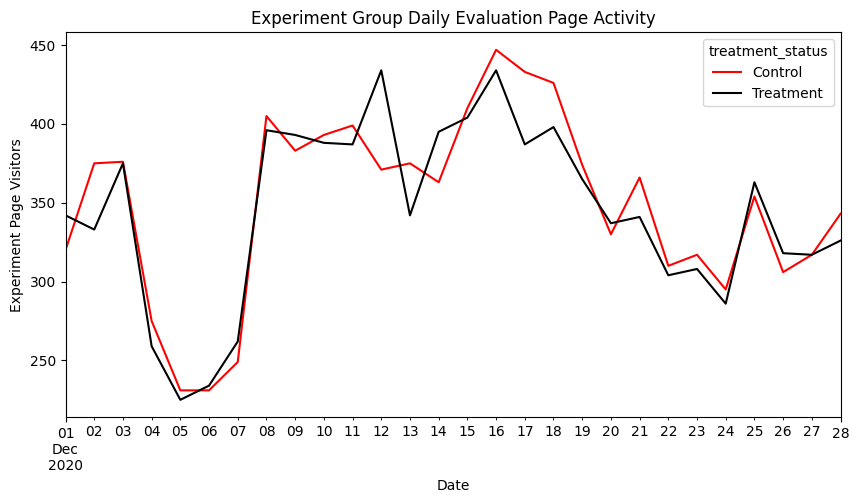

### Experiment Group Daily Purchase Activity Plot

**Step 3:** Plot Purchases by Evaluation Page First Arrival Date in Times Series

**Note:** We could also use purchase date for participants.

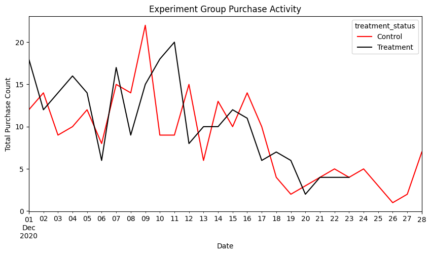

**Conclusion:**

1. Page traffic to the page appeared stable except early in December.
2. We may be missing treatment group purchase activity for the end of the month.

**Normally, we would check with engineers about potential errors. In this case, it is likely related to the low frequency of the purchase event.**

## C. Check Group Balance

|  | Metrics_Name | c_mean | t_mean | Control_Treatment_Ratio (%) |
| --- | --- | --- | --- | --- |
| 0 | prior_spending | 0.778765 | 0.662904 | 17.477743 |
| 1 | purchase_count | 0.109895 | 0.159979 | -31.307033 |
| 2 | days_active | 0.177546 | 0.185326 | -4.197929 |
| 3 | days_since_first_visit | 2.630561 | 2.849256 | -7.675487 |
| 4 | prior_engage_mins | 0.003954 | 0.006308 | -37.314407 |
| 5 | capped_revenue | 1.8862 | 2.431993 | -22.442243 |
| 6 | is_mobile | 0.417579 | 0.418574 | -0.23762 |
| 7 | is_new_user | 0.047408 | 0.053463 | -11.326934 |
| 8 | is_prior_purchaser | 0.006197 | 0.00667 | -7.091669 |
| 9 | is_purchaser | 0.023446 | 0.025346 | -7.499162 |

## D. Love Plot Group Balance

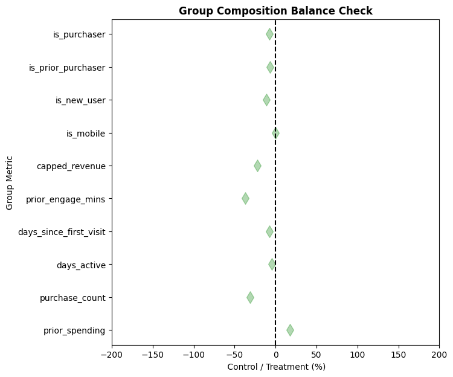

**Conclusion:** There might be a slight imbalance in the engagement minutes and prior purchase count metric. The treatment mean is percentage wise is higher for the treatment than control. Other metrics appear fairly close. We may want to look into why there might be such a large difference and whether it could adversly impact results or indicate imbalance. It may be helpful to add the covariate to a regression and see if it impacts our outcome of interest.

# VI. Experiment Results Analysis

**Goal:** This section compares average purchase conversion rates between two groups and uses a chi square test to determine whether differences are statistically signficant.

**Step 1:** Calculate purchase conversion rates for each group and plot with group specific confidence interval.

**i. Parameter Calculation**

```
Treatment Purchase Rate: 2.45%
Control Purchase Rate: 2.43%
Treatment Wald CI: 0.003
Control Wald CI: 0.003
Calculated Difference: 0.000
% Difference(T/C): 0.80
```

**ii. Plot Conversion Rate in Pointplot**

**Step 2:** Pointplot group estimates with 95% Wald confidence intervals.

|  | treatment_status | mean_estimate | Lower | Upper | color |
| --- | --- | --- | --- | --- | --- |
| 0 | Treatment | 2.449612 | 0.308031 | 0.308031 | black |
| 1 | Control | 2.430271 | 0.305629 | 0.305629 | red |

**Table:** The table above includes mean estimates and 95% Wald CIs for lower and upper error bounds.

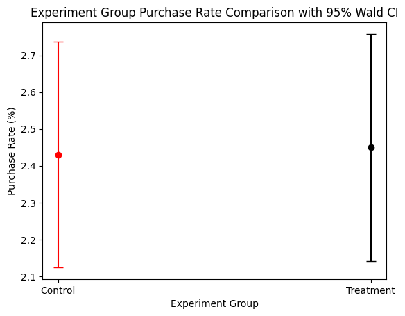

**Conclusion:** As expected in an AA Test, the pinpoint plot clearly shows the experiment group point estimates appear very similar.

**Step 3:** Calculate chi squared p-value and determine if difference was statistically significant.

```
0.9674050317193813
```

**Conclusion:** Since the p-value from the chi squared test is above .05, we do not find the difference to be statistically significant. This is the expected result given this was an AA test.

**Note:**

1. Statistically insignificant results does not mean there was no effect. A statistically insignificant result means we cannot distinguish between true observed differences in conversion rates and those relating to the variability in our data. The effect could be negative or positive. Confidence intervals tell us the predicted range.
2. 80% power means that if there was a true effect and we followed sample size requirements. We would expect to pick it up 80% of the time.

**Step 3:** Estimate confidence interval and visualize using a normal distribution plot.

**i. Parameter Calculation**

**ii. Plot Confidence Interval in Normal Distribution Graph**

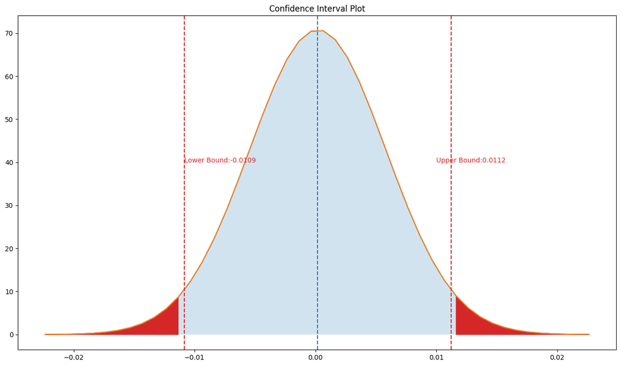